# LLMs and the wisdom of small crowds

Sean Trott

October 6, 2023

# Glasgow Concreteness Norms

## Load data

```r
### setwd("/Users/seantrott/Dropbox/UCSD/Research/NLMs/llm_clt/src/analysis/")

### Read in all data
df_all_results = read_csv("../../data/processed/gc_results.csv")
nrow(df_all_results)
```

```
## [1] 33214
```

```r
### How many per list?
table(df_all_results$list_num)
```

```
##
##    1    2    3    4    5    6    7    8    9   10   11   12   13   14   15   16
##  126 1022 2046  510 2046 3086 2046 3086 3086  510 2046 3086 3086 3086 2046  254
##   17
## 2046
```

```r
### LLM data
df_llm = read_csv("../../data/processed/gc_llm_corrs.csv")
df_llm %>%
  summarise(m_spearmam = mean(spearman_llm),
            sd_spearman = sd(spearman_llm))
```

```
## # A tibble: 1 × 2
##   m_spearmam sd_spearman
##        <dbl>       <dbl>
## 1      0.803      0.0413
```

## Figure 1a

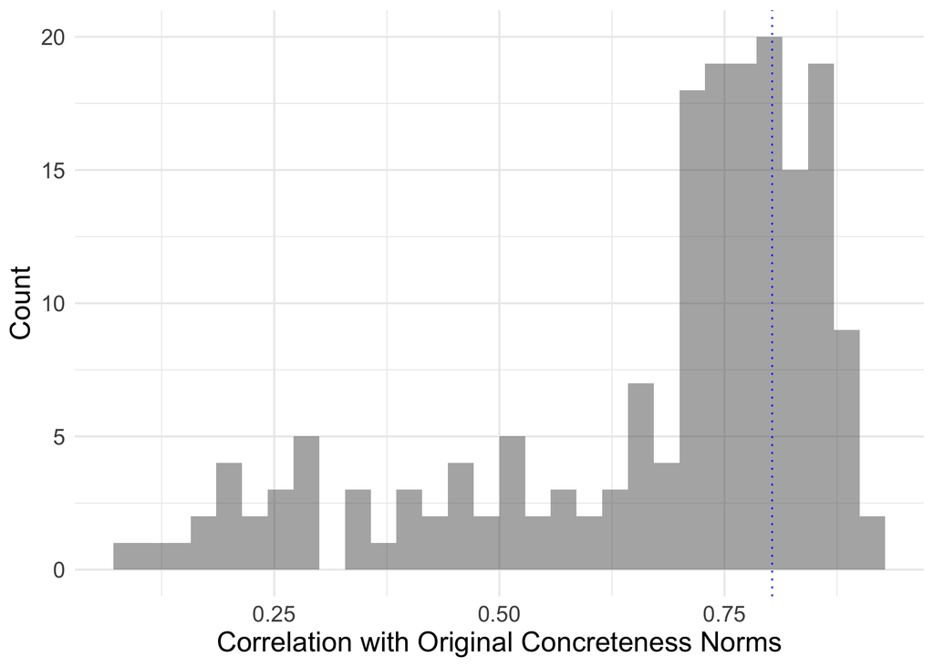

```r
df_individuals = df_all_results %>%
  filter(k == 1)

df_individuals %>%
  ggplot(aes(x = spearman_ppt)) +
  geom_histogram(alpha = .5) +
  labs(x="Correlation with Original Concreteness Norms", y="Count") +
  theme_minimal() +
  geom_vline(xintercept = mean(df_llm$spearman_llm), ### LLM
              linetype = "dotted", color = "blue", alpha = .8) +
  theme(text = element_text(size = 15))
```

## Figure 1b

```r
### Pivot
df_results_long = df_all_results %>%
  select('spearman_centaur1', 'spearman_centaur2', 'spearman_ppt',
         'k', 'combo_index', 'list_num') %>%
  pivot_longer(cols = c('spearman_centaur1', 'spearman_centaur2', 'spearman_ppt'),
               names_to = "sample_type",
               values_to = "correlation") %>%
  mutate(sample_type = sub("spearman_", "", sample_type)) %>%
  mutate(sample_type = ifelse(
    sample_type == "ppt", "Human", sample_type
  ))


### Visualize
df_results_summ = df_results_long %>%
  group_by(k, sample_type) %>%
  summarize(m_corr = mean(correlation),
            sd_corr = sd(correlation),
            se_corr = sd(correlation)/sqrt(n()))  %>%
  mutate(sample_type = toTitleCase(sample_type))
```

[output not shown]

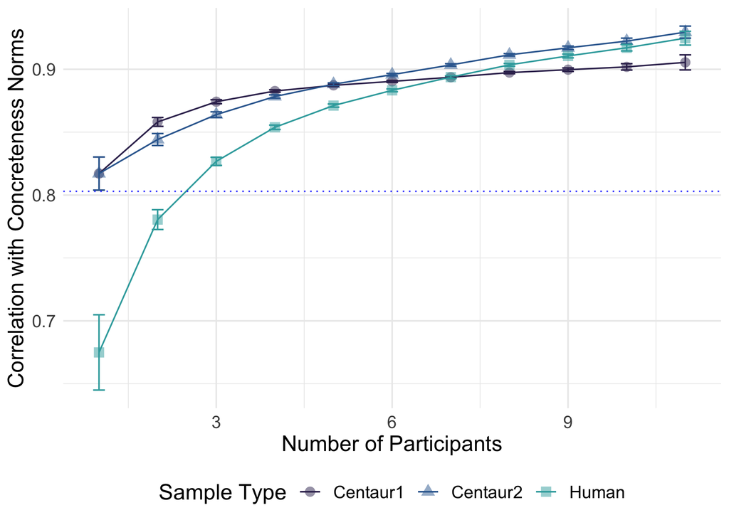

```r
df_results_summ %>%
  ggplot(aes(x = k, y = m_corr)) +
  geom_point(aes(color=factor(sample_type), shape = factor(sample_type)), size=3, alpha = .5) +  # Add points
  geom_line(aes(color=factor(sample_type))) +  # Connect points with lines
  geom_errorbar(aes(ymin=m_corr-se_corr * 2, ymax=m_corr+se_corr * 2, width=0.2, color = factor(sample_type))) +
  labs(x="Number of Participants", y="Correlation with Concreteness Norms", color = "Sample Type", shape = "Sample Type") +
  theme_minimal() +
  geom_hline(yintercept = mean(df_llm$spearman_llm), ### LLM
              linetype = "dotted", color = "blue",
            alpha = .8) +
  theme(text = element_text(size = 15),
        legend.position="bottom") +
scale_color_manual(values = my_colors)
```

## Figure 1c

Here, we visualize projected differences in **quality** and **cost** of a human sample vs. GPT-4.

### Setting up cost assumptions

For human cost, we assume:

- Rate of $12 an hour.
- Approximately 5 seconds per judgment.
- Approximately ~720 judgments per hour.

For GPT-4 cost, we assume:

```r
### Human assumptions
RATE = 12
SECONDS_PER_JUDGMENT = 5

HUMAN_CPJ = RATE / (3600/SECONDS_PER_JUDGMENT)

### GPT-4 assumptions
COST_PER_1K_SAMPLED = 0.0003
COST_PER_1K_GENERATED = 0.0006
NUM_SAMPLED_PER_JUDGMENT = 20
NUM_GENERATED_PER_JUDGMENT = 10

GPT_CPJ = (NUM_SAMPLED_PER_JUDGMENT / 1000) * COST_PER_1K_SAMPLED + 1000 * (NUM_GENERATED_PER_JUDGMENT / 1000) * COST_PER_1K_GENERATED
```

### Visualizing

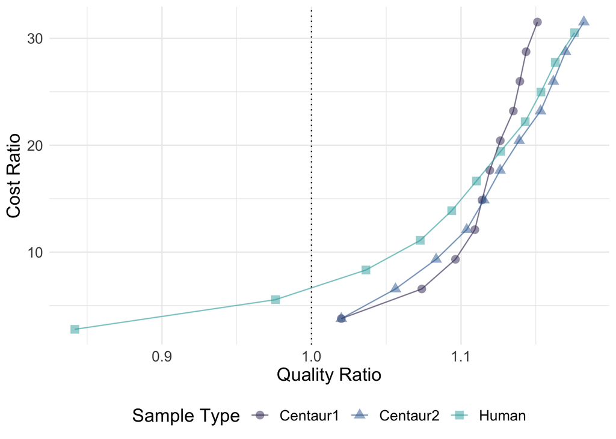

```r
### Visualize

df_costs_summ = df_all_results %>%
  mutate(ratio_human_quality = spearman_ppt / spearman_llm) %>%
  mutate(ratio_human_cost = (k * HUMAN_CPJ) / GPT_CPJ) %>%
  mutate(ratio_centaur1_quality = spearman_centaur1 / spearman_llm) %>%
  mutate(ratio_centaur1_cost = (GPT_CPJ + k * HUMAN_CPJ) / GPT_CPJ) %>%
  mutate(ratio_centaur2_quality = spearman_centaur2 / spearman_llm) %>%
  mutate(ratio_centaur2_cost = (GPT_CPJ + k * HUMAN_CPJ) / GPT_CPJ) %>%
  group_by(k) %>%
  summarise(m_human_ratio_quality = mean(ratio_human_quality),
            se_human_ratio_quality = sd(ratio_human_quality)/sqrt(n()),
            m_human_ratio_cost = mean(ratio_human_cost),
            se_human_ratio_cost = sd(ratio_human_cost),
            ### Centaur1
            m_centaur1_ratio_quality = mean(ratio_centaur1_quality),
            se_centaur1_ratio_quality = sd(ratio_centaur1_quality)/sqrt(n()),
            m_centaur1_ratio_cost = mean(ratio_centaur1_cost),
            se_centaur1_ratio_cost = sd(ratio_centaur1_cost),
            ### Centaur2
            m_centaur2_ratio_quality = mean(ratio_centaur2_quality),
            se_centaur2_ratio_quality = sd(ratio_centaur2_quality)/sqrt(n()),
            m_centaur2_ratio_cost = mean(ratio_centaur2_cost),
            se_centaur2_ratio_cost = sd(ratio_centaur2_cost))

df_costs_summ_long <- df_costs_summ %>%
  pivot_longer(
    cols = -k,
    names_to = "variable",
    values_to = "value"
  ) %>%
  mutate(
    sample_type = str_extract(variable, "human|centaur1|centaur2"),
    metric = case_when(
      str_detect(variable, "m_.*_quality") ~ "m_quality",
      str_detect(variable, "se_.*_quality") ~ "se_quality",
      str_detect(variable, "m_.*_cost") ~ "m_cost",
      str_detect(variable, "se_.*_cost") ~ "se_cost"
    )
  ) %>%
  select(-variable) %>%
  pivot_wider(
    names_from = metric,
    values_from = value
  ) %>%
  mutate(sample_type = toTitleCase(sample_type))


df_costs_summ_long %>%
  ggplot(aes(x = m_quality, y = m_cost, color = sample_type, shape = sample_type)) +
  geom_point(size=3, alpha = .5) +  # Add points
  geom_line(alpha = .6) +  # Connect points with lines
  labs(x="Quality Ratio", y="Cost Ratio",
       color = "Sample Type", shape = "Sample Type") +
  theme_minimal() +
  geom_vline(xintercept = 1, linetype = "dotted") +
  theme(text = element_text(size = 15),
        legend.position="bottom") +
  scale_color_manual(values = my_colors)
```

# RAW-C Norms

## Load data

```r
### Read in all data
df_all_results = read_csv("../../data/processed/rawc_results.csv")
nrow(df_all_results)
```

```
## [1] 21340
```

```r
### How many per list?
table(df_all_results$list_num)
```

```
##
##    1    2    3    4    5    6    7    8
## 3086 3754  510 4438 1022 3754 3754 1022
```

```r
### LLM data
df_llm = read_csv("../../data/processed/rawc_llm_corrs.csv")
df_llm %>%
  summarise(m_spearmam = mean(spearman_llm),
            sd_spearman = sd(spearman_llm))
```

```
## # A tibble: 1 × 2
##   m_spearmam sd_spearman
##        <dbl>       <dbl>
## 1      0.804      0.0205
```

## Figure 1d

```r
df_individuals = df_all_results %>%
  filter(k == 1)

mean(df_individuals$spearman_ppt)
```

```
## [1] 0.7762202
```

```r
sd(df_individuals$spearman_ppt)
```

```
## [1] 0.103045
```

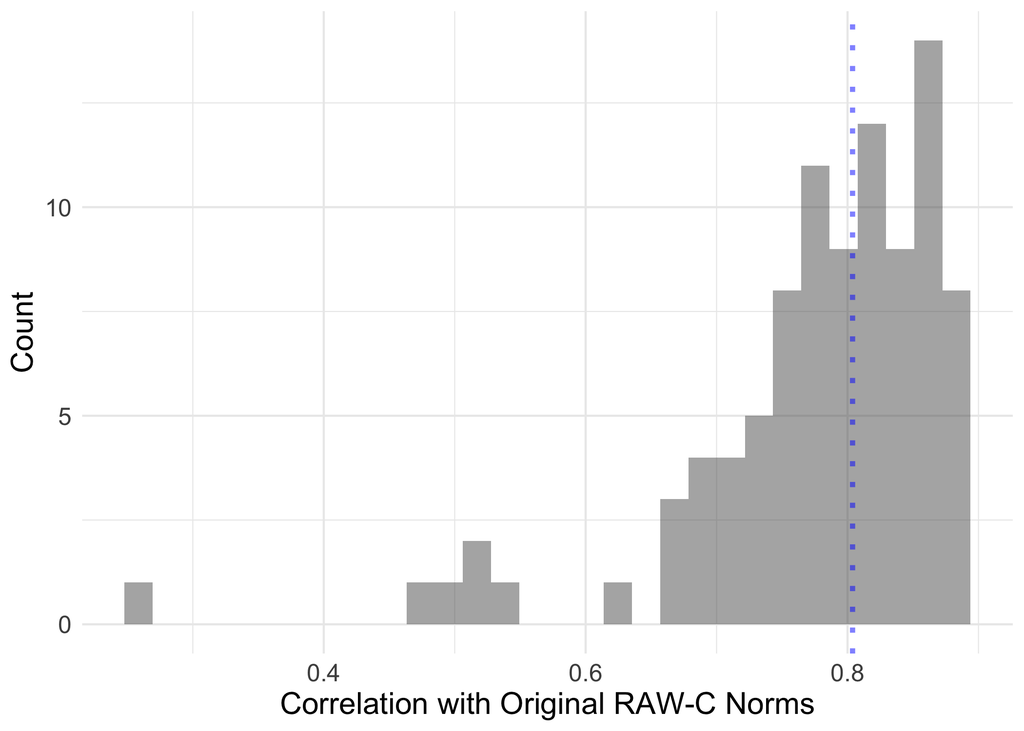

```r
df_individuals %>%
  ggplot(aes(x = spearman_ppt)) +
  geom_histogram(alpha = .5) +
  labs(x="Correlation with Original RAW-C Norms", y="Count") +
  theme_minimal() +
  geom_vline(xintercept = mean(df_llm$spearman_llm), ### LLM
              linetype = "dotted", color = "blue",
             size = 1.2, alpha = .5) +
  theme(text = element_text(size = 15))
```

## Figure 1e

```r
### Pivot
df_results_long = df_all_results %>%
  select('spearman_centaur1', 'spearman_centaur2', 'spearman_ppt',
         'k', 'combo_index', 'list_num') %>%
  pivot_longer(cols = c('spearman_centaur1', 'spearman_centaur2', 'spearman_ppt'),
               names_to = "sample_type",
               values_to = "correlation") %>%
  mutate(sample_type = sub("spearman_", "", sample_type)) %>%
  mutate(sample_type = ifelse(
    sample_type == "ppt", "Human", sample_type
  ))


### Visualize
df_results_summ = df_results_long %>%
  group_by(k, sample_type) %>%
  summarize(m_corr = mean(correlation),
            sd_corr = sd(correlation),
            se_corr = sd(correlation)/sqrt(n()))  %>%
  mutate(sample_type = toTitleCase(sample_type))
```

[output not shown]

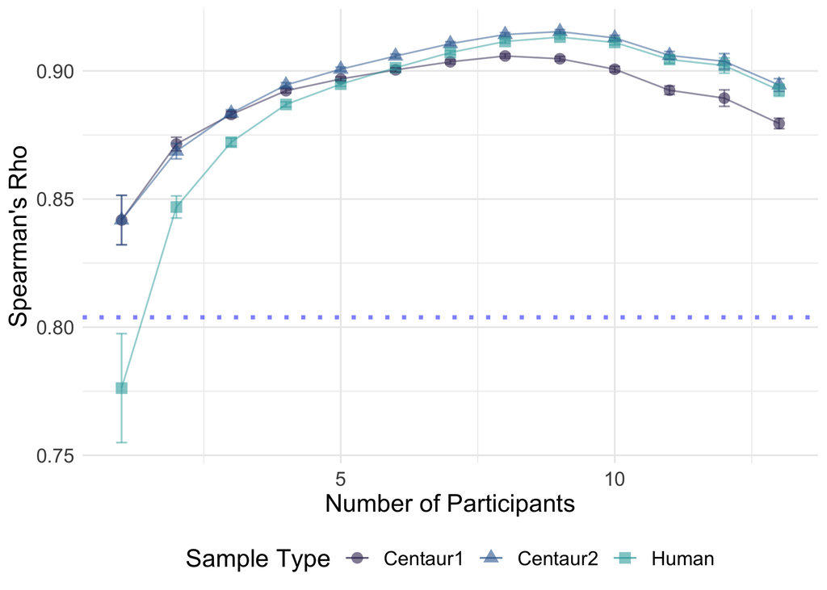

```r
df_results_summ %>%
  ggplot(aes(x = k, y = m_corr)) +
  geom_point(aes(color=factor(sample_type),shape = factor(sample_type)), size =3, alpha = .6) +  # Add points
  geom_line(aes(color=factor(sample_type)), alpha = .5) +  # Connect points with lines
  geom_errorbar(aes(ymin=m_corr-se_corr * 2, ymax=m_corr+se_corr * 2, width=0.2, color = factor(sample_type)), alpha = .5) +
  labs(x="Number of Participants", y="Spearman's Rho", color = "Sample Type",
       shape = "Sample Type") +
  theme_minimal() +
  geom_hline(yintercept = mean(df_llm$spearman_llm), ### LLM
              linetype = "dotted", color = "blue",
             size = 1.2, alpha = .5) +
  theme(text = element_text(size = 15),
        legend.position="bottom")+
  scale_color_manual(values = my_colors)
```

## Figure 1f

### Setting up cost assumptions

For human cost, we assume:

- Rate of $12 an hour.
- Approximately 5 seconds per judgment.
- Approximately ~720 judgments per hour.

For GPT-4 cost, we assume:

```r
### Human assumptions
RATE = 12
SECONDS_PER_JUDGMENT = 5

HUMAN_CPJ = RATE / (3600/SECONDS_PER_JUDGMENT)

### GPT-4 assumptions
COST_PER_1K_SAMPLED = 0.0003
COST_PER_1K_GENERATED = 0.0006
NUM_SAMPLED_PER_JUDGMENT = 20
NUM_GENERATED_PER_JUDGMENT = 10

GPT_CPJ = (NUM_SAMPLED_PER_JUDGMENT / 1000) * COST_PER_1K_SAMPLED + 1000 * (NUM_GENERATED_PER_JUDGMENT / 1000) * COST_PER_1K_GENERATED
```

### Visualizing

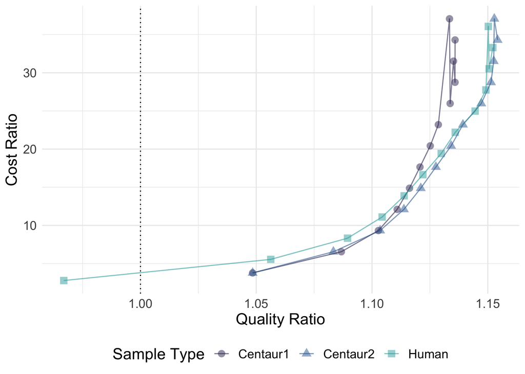

```r
### Visualize

df_costs_summ = df_all_results %>%
  mutate(ratio_human_quality = spearman_ppt / spearman_llm) %>%
  mutate(ratio_human_cost = (k * HUMAN_CPJ) / GPT_CPJ) %>%
  mutate(ratio_centaur1_quality = spearman_centaur1 / spearman_llm) %>%
  mutate(ratio_centaur1_cost = (GPT_CPJ + k * HUMAN_CPJ) / GPT_CPJ) %>%
  mutate(ratio_centaur2_quality = spearman_centaur2 / spearman_llm) %>%
  mutate(ratio_centaur2_cost = (GPT_CPJ + k * HUMAN_CPJ) / GPT_CPJ) %>%
  group_by(k) %>%
  summarise(m_human_ratio_quality = mean(ratio_human_quality),
            se_human_ratio_quality = sd(ratio_human_quality)/sqrt(n()),
            m_human_ratio_cost = mean(ratio_human_cost),
            se_human_ratio_cost = sd(ratio_human_cost),
            ### Centaur1
            m_centaur1_ratio_quality = mean(ratio_centaur1_quality),
            se_centaur1_ratio_quality = sd(ratio_centaur1_quality)/sqrt(n()),
            m_centaur1_ratio_cost = mean(ratio_centaur1_cost),
            se_centaur1_ratio_cost = sd(ratio_centaur1_cost),
            ### Centaur2
            m_centaur2_ratio_quality = mean(ratio_centaur2_quality),
            se_centaur2_ratio_quality = sd(ratio_centaur2_quality)/sqrt(n()),
            m_centaur2_ratio_cost = mean(ratio_centaur2_cost),
            se_centaur2_ratio_cost = sd(ratio_centaur2_cost))

df_costs_summ_long <- df_costs_summ %>%
  pivot_longer(
    cols = -k,
    names_to = "variable",
    values_to = "value"
  ) %>%
  mutate(
    sample_type = str_extract(variable, "human|centaur1|centaur2"),
    metric = case_when(
      str_detect(variable, "m_.*_quality") ~ "m_quality",
      str_detect(variable, "se_.*_quality") ~ "se_quality",
      str_detect(variable, "m_.*_cost") ~ "m_cost",
      str_detect(variable, "se_.*_cost") ~ "se_cost"
    )
  ) %>%
  select(-variable) %>%
  pivot_wider(
    names_from = metric,
    values_from = value
  ) %>%
  mutate(sample_type = toTitleCase(sample_type))

df_costs_summ_long %>%
  ggplot(aes(x = m_quality, y = m_cost, color = sample_type, shape = sample_type)) +
  geom_point(size=3, alpha = .5) +  # Add points
  geom_line(alpha = .6) +  # Connect points with lines
  # geom_smooth(alpha = .2) +
  labs(x="Quality Ratio", y="Cost Ratio",
       color = "Sample Type", shape = "Sample Type") +
  theme_minimal() +
  geom_vline(xintercept = 1, linetype = "dotted") +
  theme(text = element_text(size = 15),
        legend.position="bottom") +
  scale_color_manual(values = my_colors)
```

# Glasgow Valence Norms

## Load data

```r
### setwd("/Users/seantrott/Dropbox/UCSD/Research/NLMs/llm_clt/src/analysis/")

### Read in all data
df_all_results = read_csv("../../data/processed/gc_valence_results.csv")
nrow(df_all_results)
```

```
## [1] 14294
```

```r
### How many per list?
table(df_all_results$list_num)
```

```
##
##    1    2    3    4    5    6    7    8    9   10   11   12   13   14   15   16
##   62  126 2046   62  510 5150 3086  254  254  510  510 1022  126  254   62    6
##   17
##  254
```

```r
### LLM data
df_llm = read_csv("../../data/processed/gc_valence_llm_corrs.csv")
df_llm %>%
  summarise(m_spearmam = mean(spearman_llm),
            sd_spearman = sd(spearman_llm))
```

```
## # A tibble: 1 × 2
##   m_spearmam sd_spearman
##        <dbl>       <dbl>
## 1      0.750      0.0678
```

## Figure 1g

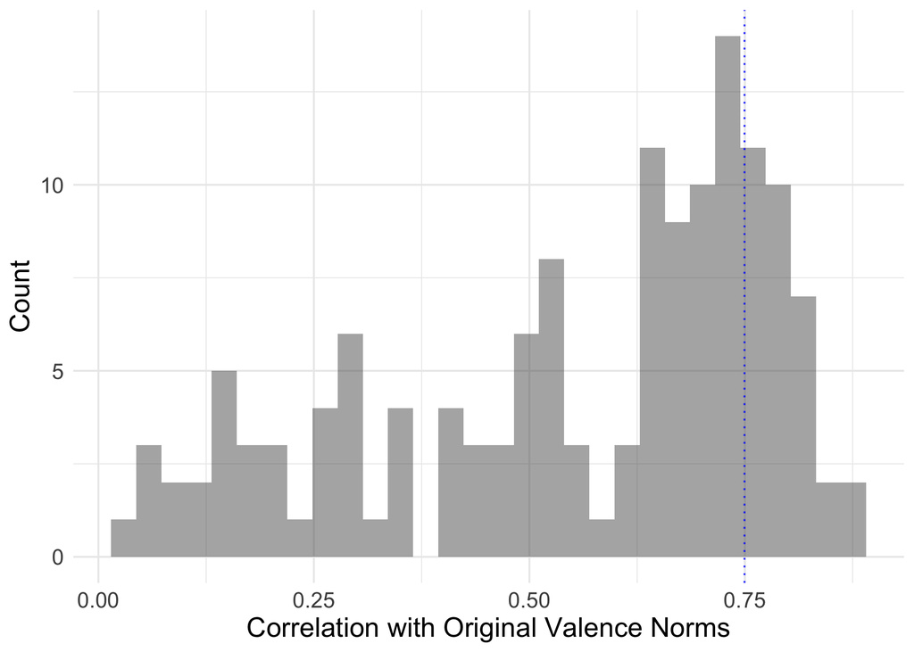

```r
df_individuals = df_all_results %>%
  filter(k == 1)

df_individuals %>%
  ggplot(aes(x = spearman_ppt)) +
  geom_histogram(alpha = .5) +
  labs(x="Correlation with Original Valence Norms", y="Count") +
  theme_minimal() +
  geom_vline(xintercept = mean(df_llm$spearman_llm), ### LLM
              linetype = "dotted", color = "blue", alpha = .8) +
  theme(text = element_text(size = 15))
```

## Figure 1h

```r
### Pivot
df_results_long = df_all_results %>%
  select('spearman_centaur1', 'spearman_centaur2', 'spearman_ppt',
         'k', 'combo_index', 'list_num') %>%
  pivot_longer(cols = c('spearman_centaur1', 'spearman_centaur2', 'spearman_ppt'),
               names_to = "sample_type",
               values_to = "correlation") %>%
  mutate(sample_type = sub("spearman_", "", sample_type)) %>%
  mutate(sample_type = ifelse(
    sample_type == "ppt", "Human", sample_type
  ))


### Visualize
df_results_summ = df_results_long %>%
  group_by(k, sample_type) %>%
  summarize(m_corr = mean(correlation),
            sd_corr = sd(correlation),
            se_corr = sd(correlation)/sqrt(n()))  %>%
  mutate(sample_type = toTitleCase(sample_type))
```

[output not shown]

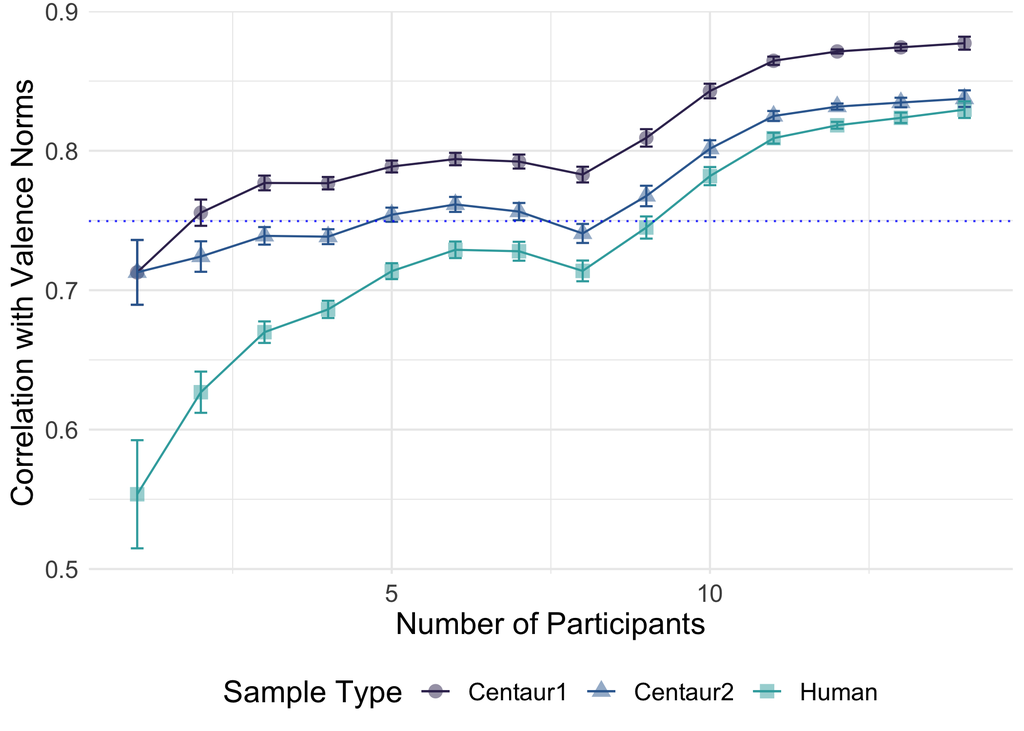

```r
df_results_summ %>%
  ggplot(aes(x = k, y = m_corr)) +
  geom_point(aes(color=factor(sample_type), shape = factor(sample_type)), size=3, alpha = .5) +  # Add points
  geom_line(aes(color=factor(sample_type))) +  # Connect points with lines
  geom_errorbar(aes(ymin=m_corr-se_corr * 2, ymax=m_corr+se_corr * 2, width=0.2, color = factor(sample_type))) +
  labs(x="Number of Participants", y="Correlation with Valence Norms", color = "Sample Type", shape = "Sample Type") +
  theme_minimal() +
  geom_hline(yintercept = mean(df_llm$spearman_llm), ### LLM
              linetype = "dotted", color = "blue",
            alpha = .8) +
  theme(text = element_text(size = 15),
        legend.position="bottom") +
scale_color_manual(values = my_colors)
```

## Figure 1i

Here, we visualize projected differences in **quality** and **cost** of a human sample vs. GPT-4.

### Setting up cost assumptions

For human cost, we assume:

- Rate of $12 an hour.
- Approximately 5 seconds per judgment.
- Approximately ~720 judgments per hour.

For GPT-4 cost, we assume:

```r
### Human assumptions
RATE = 12
SECONDS_PER_JUDGMENT = 5

HUMAN_CPJ = RATE / (3600/SECONDS_PER_JUDGMENT)

### GPT-4 assumptions
COST_PER_1K_SAMPLED = 0.0003
COST_PER_1K_GENERATED = 0.0006
NUM_SAMPLED_PER_JUDGMENT = 20
NUM_GENERATED_PER_JUDGMENT = 10

GPT_CPJ = (NUM_SAMPLED_PER_JUDGMENT / 1000) * COST_PER_1K_SAMPLED + 1000 * (NUM_GENERATED_PER_JUDGMENT / 1000) * COST_PER_1K_GENERATED
```

### Visualizing

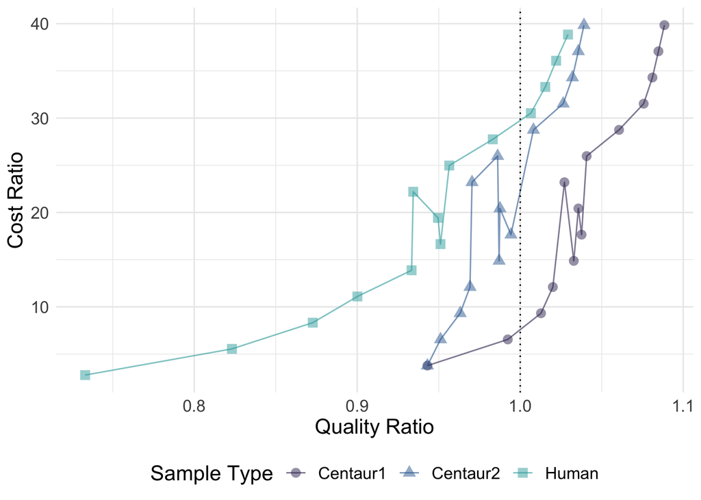

```r
### Visualize

df_costs_summ = df_all_results %>%
  mutate(ratio_human_quality = spearman_ppt / spearman_llm) %>%
  mutate(ratio_human_cost = (k * HUMAN_CPJ) / GPT_CPJ) %>%
  mutate(ratio_centaur1_quality = spearman_centaur1 / spearman_llm) %>%
  mutate(ratio_centaur1_cost = (GPT_CPJ + k * HUMAN_CPJ) / GPT_CPJ) %>%
  mutate(ratio_centaur2_quality = spearman_centaur2 / spearman_llm) %>%
  mutate(ratio_centaur2_cost = (GPT_CPJ + k * HUMAN_CPJ) / GPT_CPJ) %>%
  group_by(k) %>%
  summarise(m_human_ratio_quality = mean(ratio_human_quality),
            se_human_ratio_quality = sd(ratio_human_quality)/sqrt(n()),
            m_human_ratio_cost = mean(ratio_human_cost),
            se_human_ratio_cost = sd(ratio_human_cost),
            ### Centaur1
            m_centaur1_ratio_quality = mean(ratio_centaur1_quality),
            se_centaur1_ratio_quality = sd(ratio_centaur1_quality)/sqrt(n()),
            m_centaur1_ratio_cost = mean(ratio_centaur1_cost),
            se_centaur1_ratio_cost = sd(ratio_centaur1_cost),
            ### Centaur2
            m_centaur2_ratio_quality = mean(ratio_centaur2_quality),
            se_centaur2_ratio_quality = sd(ratio_centaur2_quality)/sqrt(n()),
            m_centaur2_ratio_cost = mean(ratio_centaur2_cost),
            se_centaur2_ratio_cost = sd(ratio_centaur2_cost))

df_costs_summ_long <- df_costs_summ %>%
  pivot_longer(
    cols = -k,
    names_to = "variable",
    values_to = "value"
  ) %>%
  mutate(
    sample_type = str_extract(variable, "human|centaur1|centaur2"),
    metric = case_when(
      str_detect(variable, "m_.*_quality") ~ "m_quality",
      str_detect(variable, "se_.*_quality") ~ "se_quality",
      str_detect(variable, "m_.*_cost") ~ "m_cost",
      str_detect(variable, "se_.*_cost") ~ "se_cost"
    )
  ) %>%
  select(-variable) %>%
  pivot_wider(
    names_from = metric,
    values_from = value
  ) %>%
  mutate(sample_type = toTitleCase(sample_type))


df_costs_summ_long %>%
  ggplot(aes(x = m_quality, y = m_cost, color = sample_type, shape = sample_type)) +
  geom_point(size=3, alpha = .5) +  # Add points
  geom_line(alpha = .6) +  # Connect points with lines
  labs(x="Quality Ratio", y="Cost Ratio",
       color = "Sample Type", shape = "Sample Type") +
  theme_minimal() +
  geom_vline(xintercept = 1, linetype = "dotted") +
  theme(text = element_text(size = 15),
        legend.position="bottom") +
  scale_color_manual(values = my_colors)
```